# Olympics2016

Deepal Singh

January 11, 2019

## Data Curation and Parsing

Data Curation is an important step during the data analysis process. It provides meaningful access to the data.It involves constructing a structure that sorts the data into a meaningful retrieval system and gives us intellectual control over content.

### Importing the libraries and reading table from url

```r
library(dplyr)
library(tidyr)
library(tidyverse)
library(stringr)
library(naniar)
library(measurements)


olympics_data <- read.csv(file = "C:\\Users\\Mandevi\\Documents\\athletes.csv", na.strings = c("", " ", "NA"), stringsAsFactors = FALSE)

as_data_frame(olympics_data)
```

```
## # A tibble: 11,538 x 11
##        id name  nationality sex   dob   height weight sport  gold silver
##     <int> <chr> <chr>       <chr> <chr>  <dbl>  <int> <chr> <int>  <int>
##  1 7.36e8 A Je~ ESP         male  10/1~   1.72     64 athl~     0      0
##  2 5.32e8 A La~ KOR         fema~ 9/23~   1.68     56 fenc~     0      0
##  3 4.36e8 Aaro~ CAN         male  5/27~   1.98     79 athl~     0      0
##  4 5.21e8 Aaro~ MDA         male  1/2/~   1.83     80 taek~     0      0
##  5 3.39e7 Aaro~ NZL         male  11/2~   1.81     71 cycl~     0      0
##  6 1.73e8 Aaro~ AUS         male  1/26~   1.8      67 tria~     0      0
##  7 2.66e8 Aaro~ USA         male  6/4/~   2.05     98 voll~     0      0
##  8 3.83e8 Aaro~ AUS         male  9/25~   1.93    100 aqua~     0      0
##  9 8.77e7 Aaur~ ESP         fema~ 12/1~   1.8      62 athl~     0      0
## 10 9.98e8 Abab~ ETH         fema~ 7/22~   1.65     54 athl~     0      0
## # ... with 11,528 more rows, and 1 more variable: bronze <int>
```

### Tidying the data

This section includes data preparation, that is taking raw datasets and make changes to turn messy data into tidy data. If we open the url and see the table, we can observe that there are lots of things that can be made simple. For instance,I have converted date of birth to age and also renamed variables for readability.

```r
library(eeptools)
library(lubridate)
# Removing id because we don't need it
tidy_olympics<- subset(olympics_data, select = -c(id))%>%
  na.omit(olympics_data)

# meter to feet and inches function
ft_and_inches <- conv_unit(tidy_olympics$height, "m", "ft")
tidy_olympics$height<- round(ft_and_inches, digits = 2)

#  changing dob to age
conv_age <- function(dob, age.day = Sys.Date(), units = "years", floor = TRUE) {
    calc.age = interval(dob, age.day) / duration(num = 1, units = units)
    if (floor)
      return(as.integer(floor(calc.age)))
    return(calc.age)
}

tidy_olympics$dob <- as.Date(tidy_olympics$dob, format = "%m/%d/%y")
tidy_olympics$dob <- conv_age(tidy_olympics$dob)

# renaming the nationality into Country_code
names(tidy_olympics)[names(tidy_olympics)== "nationality"] <-"Country_Code"
names(tidy_olympics)[names(tidy_olympics)== "dob"] <-"age"
names(tidy_olympics)[names(tidy_olympics)== "name"] <-"Athlete_name"

as_data_frame(tidy_olympics)
```

```
## # A tibble: 10,858 x 10
##    Athlete_name Country_Code sex     age height weight sport  gold silver
##    <chr>        <chr>        <chr> <int>  <dbl>  <int> <chr> <int>  <int>
##  1 A Jesus Gar~ ESP          male     49   5.64     64 athl~     0      0
##  2 A Lam Shin   KOR          fema~    32   5.51     56 fenc~     0      0
##  3 Aaron Brown  CAN          male     26   6.5      79 athl~     0      0
##  4 Aaron Cook   MDA          male     28   6        80 taek~     0      0
##  5 Aaron Gate   NZL          male     28   5.94     71 cycl~     0      0
##  6 Aaron Royle  AUS          male     29   5.91     67 tria~     0      0
##  7 Aaron Russe~ USA          male     25   6.73     98 voll~     0      0
##  8 Aaron Young~ AUS          male     27   6.33    100 aqua~     0      0
##  9 Aauri Loren~ ESP          fema~    30   5.91     62 athl~     0      0
## 10 Ababel Yesh~ ETH          fema~    27   5.41     54 athl~     0      0
## # ... with 10,848 more rows, and 1 more variable: bronze <int>
```

## Exploratory Data Analysis

Exploratory Data Analysis helps to better understand the tidy data, and help us make decisions about appropriate statistical or Machine Learning methods, or data transformations.

### Number of medals won by country

This table is on the country winning higher number of medals and USA has highest wins.

```r
tidy_olympics$Total_medals = rowSums(tidy_olympics[,8:10])

olympics_data_subset<- tidy_olympics%>%
  filter(Total_medals != 0)%>%
  select("Athlete_name","Country_Code","sex", "sport", "Total_medals")%>%
  arrange(Country_Code)


country <- olympics_data_subset%>%
  group_by(Country_Code)%>%
  summarise(total_wins = sum(Total_medals))%>%
  arrange(desc(total_wins))
country
```

```
## # A tibble: 82 x 2
##    Country_Code total_wins
##    <chr>             <dbl>
##  1 USA                 258
##  2 GER                 159
##  3 GBR                 141
##  4 CHN                 109
##  5 RUS                 107
##  6 FRA                  89
##  7 AUS                  82
##  8 ITA                  72
##  9 CAN                  69
## 10 JPN                  65
## # ... with 72 more rows
```

### Popular sport according to the numbers participated

From the table below, it can be verified that many particpants take part more in aquatics.

```r
popular_sport<- olympics_data_subset%>%
  select(Country_Code, sport)%>%
  group_by(sport)%>%
  summarize(participants_num = length(sport))%>%
  arrange(desc(participants_num))

popular_sport
```

```
## # A tibble: 27 x 2
##    sport        participants_num
##    <chr>                   <int>
##  1 aquatics                  257
##  2 athletics                 165
##  3 rowing                    140
##  4 hockey                     99
##  5 football                   90
##  6 volleyball                 83
##  7 cycling                    74
##  8 handball                   74
##  9 rugby sevens               74
## 10 basketball                 72
## # ... with 17 more rows
```

### Plot of the frequency of participants playing particular sport

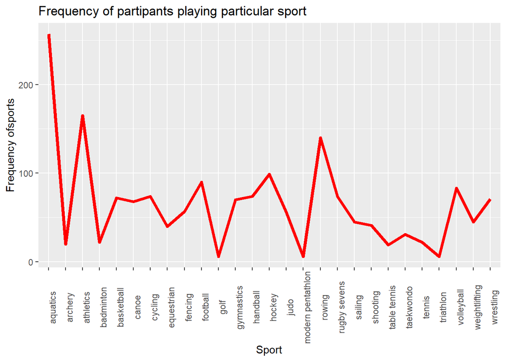

```r
popular_sport%>%
  ggplot(aes(y=participants_num, x = sport, group = 1))+
  geom_line(color= "red", size= 1.5)+
  xlab("Sport") +
  ylab("Frequency ofsports") +
  ggtitle("Frequency of partipants playing particular sport")+
   theme(axis.text.x = element_text(angle=90, hjust=0.5))
```

### Analyzing males vs females

This is the barplot to see if there is difference between males and females involved in sports. And it looks like there is not much difference. This is how my hypothesis was developed for further analysis.

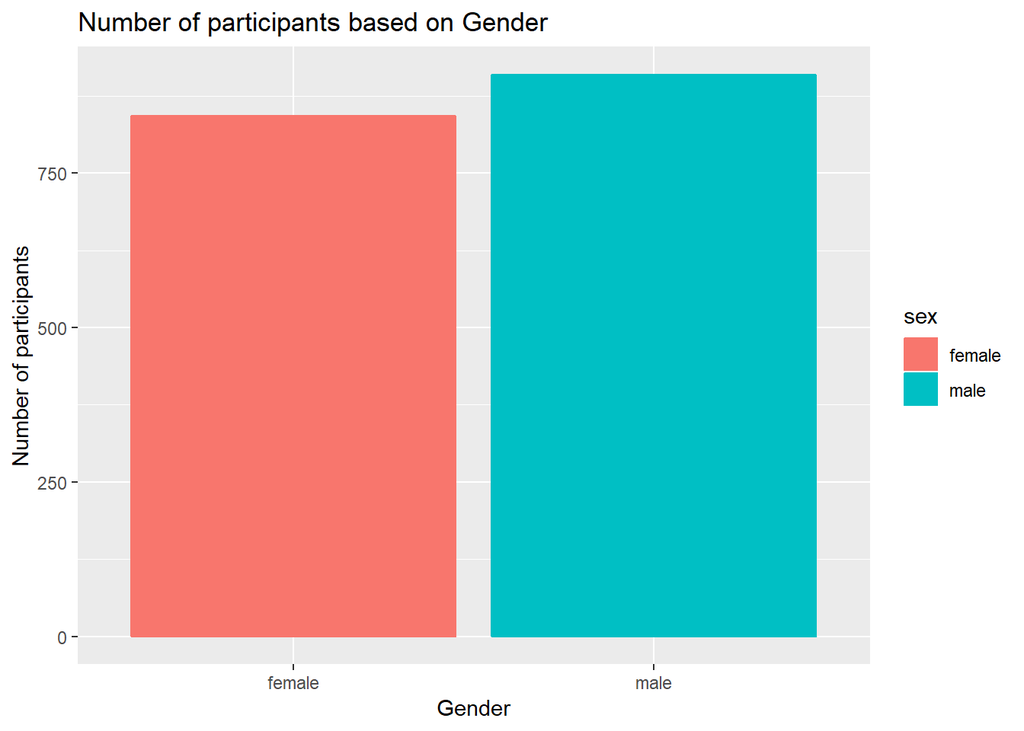

```r
gender_data<- olympics_data_subset%>%
  group_by(sex)%>%
  summarise(Gender_Count = length(sex))%>%
  ggplot(aes(x=sex, y = Gender_Count))+
  geom_bar(stat="identity", mapping = aes(fill= sex, color=sex))+
  xlab("Gender") +
  ylab("Number of participants") +
  ggtitle("Number of participants based on Gender")
gender_data
```

## Hypothesis Testing & Machine learning

I will be performing a statistical hypothetical testing. Hypothesis testing is, in a way, the formal way of validating the hypothesis claim that is made about a population. Statistical Hypothesis can be classified into into 2 types; null hypothesis and alternative hypothesis.Through EDA, I was able find that there is not much Gender differences for involvement in sports. The common stereotype is that men are most capable in physical activites and women would lag behind.So, I developed the hypothesis to test if this stereotype is really true.

### Null Hypothesis:

There is no difference bewtween males and females involved in # sports in olympics.

### Alternative Hypothesis:

There are differences between males and females involved in sports in olympics

### T_test

A t-test looks at the t-statistic, the t-distribution and degrees of freedom to determine the probability of difference between variables. I am performing a t_test with 95% confidence interval and it is going to be two sided. Confidence interval is the range of values defined such that there is specified probability that the value of parameter lies within.

```r
g_data <- olympics_data_subset%>%
  select(sport, sex)%>%
  group_by(sport, sex)%>%
  summarize(g_count = length(sex))


male <- g_data%>%filter(sex== "male")


female <- g_data%>%filter(sex == "female")

t.test(male$g_count, female$g_count, mu = 0, con4f.level = 0.95, alternative = "two.sided", paired = FALSE)
```

```
##
##  Welch Two Sample t-test
##
## data:  male$g_count and female$g_count
## t = 0.32997, df = 51.724, p-value = 0.7428
## alternative hypothesis: true difference in means is not equal to 0
## 95 percent confidence interval:
##  -12.61116  17.57413
## sample estimates:
## mean of x mean of y
##  33.70370  31.22222
```

The table shows t = 0.32997, with the degree of freedom df = 51.724. The p-value equals .7428. With this given p-value and using significance level of 0.05, we fail to reject the null hypothesis. BUt we reject the alternative hypothesis saying that there is a difference between the male and the females. Therefore, we cannot conclude that there is a significant difference between the physical qualities and sport involvement of female and male players.

A 95% confidence interval for the difference in mean count is given by

```r
difference <- male$g_count - female$g_count
t.test(difference)
```

```
##
##  One Sample t-test
##
## data:  difference
## t = 1.2284, df = 26, p-value = 0.2303
## alternative hypothesis: true mean is not equal to 0
## 95 percent confidence interval:
##  -1.670905  6.633868
## sample estimates:
## mean of x
##  2.481481
```

From the above data, the confidence interval is between -1.670905 and 6.633868. This shows that 95% of the true population mean differences between these two gender are in this intervals.

## Machine learning

### linear regression

One of the most used techniques is linear regression where we can examine the potential relationship between variable and a set of one or more variables. Therefore, I will examine linear model for gender count.Following code uses lm function to interpret the data.

```r
library(broom)

linear_model_of_gender <- lm(g_count~sex, data = g_data, family = binomial)%>%
  tidy()
linear_model_of_gender
```

```
## # A tibble: 2 x 5
##   term        estimate std.error statistic     p.value
##   <chr>          <dbl>     <dbl>     <dbl>       <dbl>
## 1 (Intercept)    31.2       5.32     5.87  0.000000307
## 2 sexmale         2.48      7.52     0.330 0.743
```

According to this model, when the male is not counted, the total number of women counterparts would be 31.222.

Following is the plot which gets a violin plot for the count of gender.

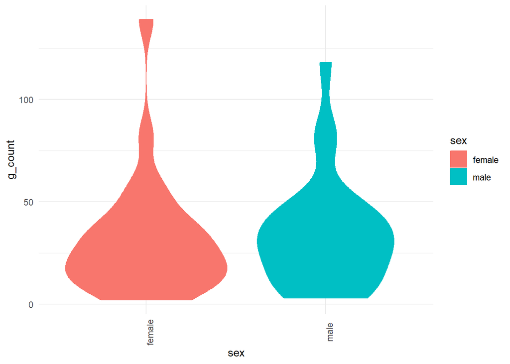

```r
plot_tree<-g_data %>%
  ggplot(aes(y = g_count, x= sex)) +
  geom_violin(aes(fill= sex, color=sex)) +
  theme_minimal()+
  theme(axis.text.x = element_text(angle=90, hjust=0.5))

plot_tree
```

### Regression for sport and G_count

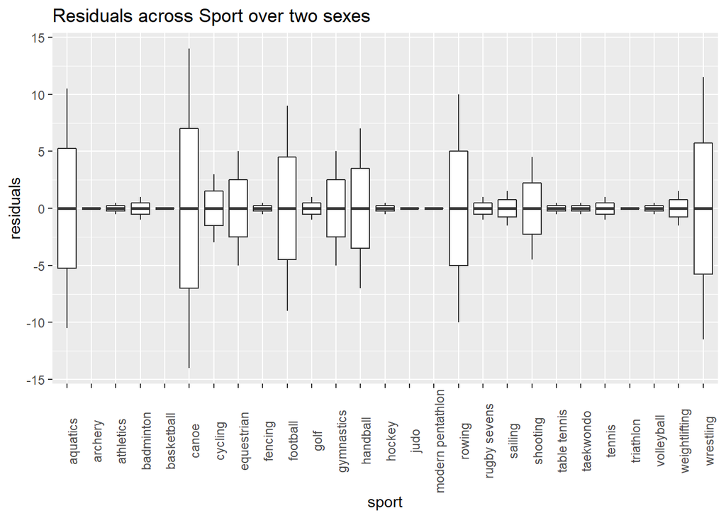

```r
regression <- lm(g_count~sport,data=g_data)%>%
  augment()
regression%>%
  ggplot(aes(x=factor(sport), y=.resid)) +
  geom_boxplot() +
  labs(title="Residuals across Sport over two sexes", x = "sport", y = "residuals")+
  theme(axis.text.x = element_text(angle=90, hjust=0.5))
```

# Plot

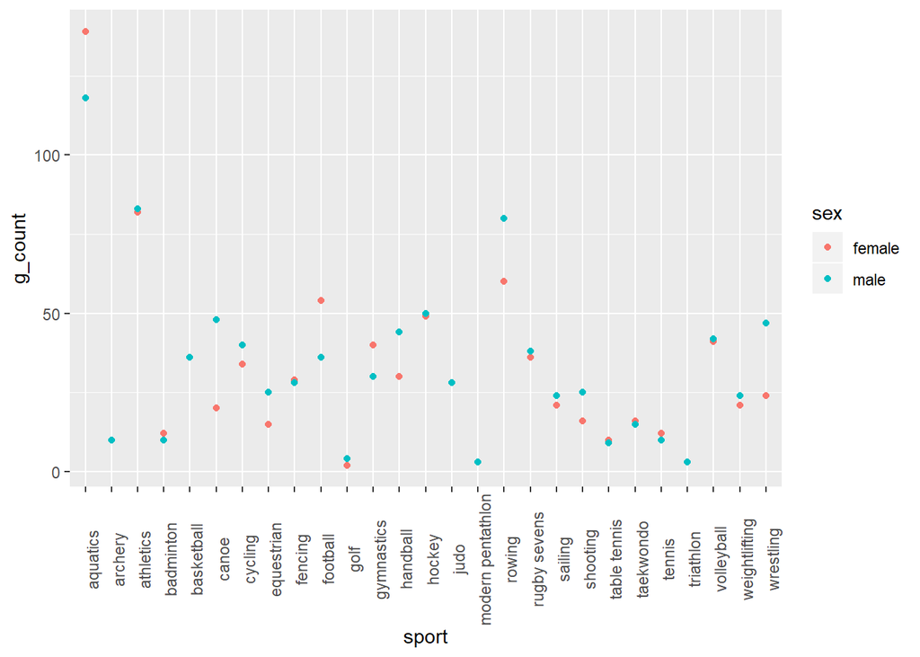

```r
g_data%>%
  ggplot(aes(y= g_count, x = sport, color = sex, group = 1))+
  geom_point()+
  theme(axis.text.x = element_text(angle=90, hjust=0.5))
```